# Comparison of ML Models and Imbalance Methods

Viet Tien Trinh & Zerui Wang

2026-05-11

# 1 Purpose

This R Markdown file compares all models and all imbalance-handling scenarios used in the thesis:

1. **No SMOTE**: models are trained directly after preprocessing.
2. **SMOTE**: synthetic minority oversampling is applied only inside the training/resampling recipe.
3. **Class weights**: the minority class receives larger weights during model training.

The main outcome variable is **Biopsy**, and the positive/minority class is assumed to be **Yes**.

For this dataset, **PR-AUC**, **MCC**, **sensitivity**, and **specificity** are more informative than accuracy because the outcome is strongly imbalanced.

# 2 Run or read model results

This section tries to read the CSV files generated by your three ML scripts. If they do not exist, it tries to run the scripts first.

```r
# Helper function: source script only if needed
source_if_needed <- function(csv_file, script_file) {
  csv_path <- file.path(base_dir, csv_file)
  script_path <- file.path(base_dir, script_file)

  if (!file.exists(csv_path)) {
    if (!file.exists(script_path)) {
      stop(paste("Missing both", csv_file, "and", script_file))
    }
    cat("CSV not found:", csv_file, "\n")
    cat("Running script:", script_file, "\n")
    source(script_path, local = .GlobalEnv)
  } else {
    cat("Found CSV:", csv_file, "\n")
  }
}

# Optional: run data handling first if df does not exist.
# Your ML scripts expect an object named df.
if (!exists("df") && file.exists(file.path(base_dir, "Thesis_hantera_NA.R"))) {
  cat("Running Thesis_hantera_NA.R to create df...\n")
  source(file.path(base_dir, "Thesis_hantera_NA.R"), local = .GlobalEnv)
}

source_if_needed("results_no_SMOTE.csv", "Thesis_ML_no_SMOTE.R")
```

```
## Found CSV: results_no_SMOTE.csv
```

```r
source_if_needed("results_SMOTE.csv", "Thesis_ML_SMOTE.R")
```

```
## Found CSV: results_SMOTE.csv
```

```r
source_if_needed("results_class_weights.csv", "Thesis_ML_class_weights.R")
```

```
## Found CSV: results_class_weights.csv
```

```r
# Read result tables
results_no_smote <- read.csv(file.path(base_dir, "results_no_SMOTE.csv")) %>%
  mutate(scenario = "No SMOTE")

results_smote <- read.csv(file.path(base_dir, "results_SMOTE.csv")) %>%
  mutate(scenario = "SMOTE")

results_class_weights <- read.csv(file.path(base_dir, "results_class_weights.csv")) %>%
  mutate(scenario = "Class weights")

all_results <- bind_rows(
  results_no_smote,
  results_smote,
  results_class_weights
) %>%
  relocate(scenario, model)

# Standardize model names so weighted and non-weighted models can be compared fairly
all_results <- all_results %>%
  mutate(
    model_clean = model %>%
      str_replace("^Weighted ", "") %>%
      str_replace("LASSO Logistic Regression", "LASSO") %>%
      str_replace("Logistic Regression", "Logistic Regression") %>%
      str_replace("Random Forest", "Random Forest") %>%
      str_replace("XGBoost", "XGBoost")
  )

all_results %>%
  arrange(desc(pr_auc)) %>%
  kable(digits = 4, caption = "All model results across all scenarios") %>%
  kable_styling(full_width = FALSE)
```

All model results across all scenarios

| scenario | model | brier_class | f_meas | mcc | pr_auc | precision | roc_auc | sens | spec | threshold | model_clean |
| --- | --- | --- | --- | --- | --- | --- | --- | --- | --- | --- | --- |
| No SMOTE | LASSO Logistic Regression | 0.8275 | NA | NA | 0.5233 | NA | 0.5000 | 0.000 | 1.0000 | 0.5000 | LASSO |
| SMOTE | LASSO Logistic Regression | 0.2500 | NA | NA | 0.5233 | NA | 0.5000 | 0.000 | 1.0000 | 0.5000 | LASSO |
| Class weights | Weighted LASSO Logistic Regression | 0.2500 | NA | NA | 0.5233 | NA | 0.5000 | 0.000 | 1.0000 | 0.5000 | LASSO |
| No SMOTE | XGBoost | 0.8280 | 0.1250 | 0.1454 | 0.3013 | 0.0667 | 0.6646 | 1.000 | 0.3171 | 0.0680 | XGBoost |
| SMOTE | Random Forest | 0.7881 | 0.2500 | 0.2934 | 0.1369 | 0.1458 | 0.8041 | 0.875 | 0.7500 | 0.1210 | Random Forest |
| Class weights | Weighted Random Forest | 0.7462 | 0.2029 | 0.2402 | 0.1248 | 0.1148 | 0.7927 | 0.875 | 0.6707 | 0.1403 | Random Forest |
| Class weights | Weighted XGBoost | 0.2803 | 0.1707 | 0.1984 | 0.1185 | 0.0946 | 0.7755 | 0.875 | 0.5915 | 0.4621 | XGBoost |
| No SMOTE | Random Forest | 0.8283 | 0.2353 | 0.2550 | 0.1089 | 0.1395 | 0.7622 | 0.750 | 0.7744 | 0.1113 | Random Forest |
| SMOTE | XGBoost | 0.8174 | 0.1972 | 0.2332 | 0.0896 | 0.1111 | 0.7386 | 0.875 | 0.6585 | 0.0709 | XGBoost |
| No SMOTE | Logistic Regression | 0.8385 | 0.2400 | 0.2044 | 0.0761 | 0.1765 | 0.5434 | 0.375 | 0.9146 | 0.0979 | Logistic Regression |
| Class weights | Weighted Logistic Regression | 0.3223 | 0.1695 | 0.1589 | 0.0735 | 0.0980 | 0.6235 | 0.625 | 0.7195 | 0.4501 | Logistic Regression |
| SMOTE | Logistic Regression | 0.3252 | 0.1231 | 0.0791 | 0.0522 | 0.0702 | 0.5069 | 0.500 | 0.6768 | 0.4545 | Logistic Regression |

# 3 Overall ranking

The table below ranks every model-scenario combination. For imbalanced classification, the most important metric is usually **PR-AUC**, followed by **MCC**. Sensitivity and specificity are used to check whether the model finds positive cases without producing too many false positives.

```r
ranking <- all_results %>%
  mutate(
    rank_pr_auc = min_rank(desc(pr_auc)),
    rank_mcc = min_rank(desc(mcc)),
    rank_roc_auc = min_rank(desc(roc_auc)),
    mean_rank = (rank_pr_auc + rank_mcc + rank_roc_auc) / 3
  ) %>%
  arrange(mean_rank, desc(pr_auc), desc(mcc))

ranking %>%
  select(scenario, model, pr_auc, mcc, roc_auc, sens, spec, precision, f_meas, brier_class, mean_rank) %>%
  kable(digits = 4, caption = "Ranking based on PR-AUC, MCC and ROC-AUC") %>%
  kable_styling(full_width = FALSE)
```

Ranking based on PR-AUC, MCC and ROC-AUC

| scenario | model | pr_auc | mcc | roc_auc | sens | spec | precision | f_meas | brier_class | mean_rank |
| --- | --- | --- | --- | --- | --- | --- | --- | --- | --- | --- |
| SMOTE | Random Forest | 0.1369 | 0.2934 | 0.8041 | 0.875 | 0.7500 | 0.1458 | 0.2500 | 0.7881 | 2.3333 |
| Class weights | Weighted Random Forest | 0.1248 | 0.2402 | 0.7927 | 0.875 | 0.6707 | 0.1148 | 0.2029 | 0.7462 | 3.6667 |
| No SMOTE | Random Forest | 0.1089 | 0.2550 | 0.7622 | 0.750 | 0.7744 | 0.1395 | 0.2353 | 0.8283 | 4.6667 |
| Class weights | Weighted XGBoost | 0.1185 | 0.1984 | 0.7755 | 0.875 | 0.5915 | 0.0946 | 0.1707 | 0.2803 | 5.3333 |
| No SMOTE | XGBoost | 0.3013 | 0.1454 | 0.6646 | 1.000 | 0.3171 | 0.0667 | 0.1250 | 0.8280 | 6.0000 |
| SMOTE | XGBoost | 0.0896 | 0.2332 | 0.7386 | 0.875 | 0.6585 | 0.1111 | 0.1972 | 0.8174 | 6.0000 |
| No SMOTE | Logistic Regression | 0.0761 | 0.2044 | 0.5434 | 0.375 | 0.9146 | 0.1765 | 0.2400 | 0.8385 | 7.6667 |
| Class weights | Weighted Logistic Regression | 0.0735 | 0.1589 | 0.6235 | 0.625 | 0.7195 | 0.0980 | 0.1695 | 0.3223 | 8.3333 |
| SMOTE | Logistic Regression | 0.0522 | 0.0791 | 0.5069 | 0.500 | 0.6768 | 0.0702 | 0.1231 | 0.3252 | 10.0000 |
| No SMOTE | LASSO Logistic Regression | 0.5233 | NA | 0.5000 | 0.000 | 1.0000 | NA | NA | 0.8275 | NA |
| SMOTE | LASSO Logistic Regression | 0.5233 | NA | 0.5000 | 0.000 | 1.0000 | NA | NA | 0.2500 | NA |
| Class weights | Weighted LASSO Logistic Regression | 0.5233 | NA | 0.5000 | 0.000 | 1.0000 | NA | NA | 0.2500 | NA |

```r
best_pr_auc <- ranking %>% arrange(desc(pr_auc)) %>% slice(1)
best_mcc <- ranking %>% arrange(desc(mcc)) %>% slice(1)
best_overall <- ranking %>% arrange(mean_rank) %>% slice(1)
```

# 4 Metric comparison plots

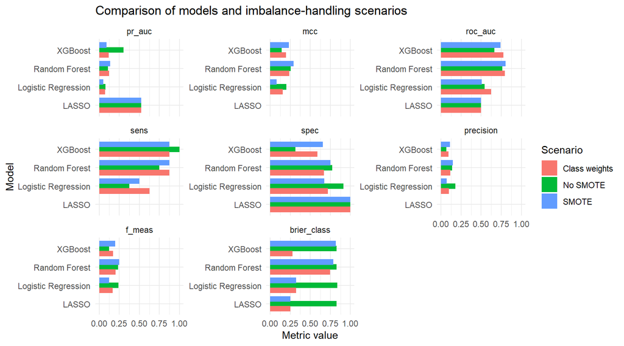

```r
all_results %>%
  pivot_longer(
    cols = any_of(c("pr_auc", "mcc", "roc_auc", "sens", "spec", "precision", "f_meas", "brier_class")),
    names_to = "metric",
    values_to = "value"
  ) %>%
  mutate(metric = factor(metric, levels = c("pr_auc", "mcc", "roc_auc", "sens", "spec", "precision", "f_meas", "brier_class"))) %>%
  ggplot(aes(x = model_clean, y = value, fill = scenario)) +
  geom_col(position = position_dodge(width = 0.8)) +
  facet_wrap(~ metric, scales = "free_y") +
  coord_flip() +
  labs(
    title = "Comparison of models and imbalance-handling scenarios",
    x = "Model",
    y = "Metric value",
    fill = "Scenario"
  ) +
  theme_minimal()
```

# 5 PR-AUC and MCC focus

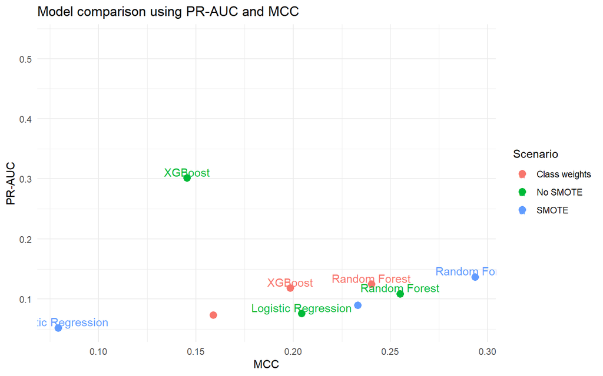

```r
all_results %>%
  ggplot(aes(x = mcc, y = pr_auc, color = scenario, label = model_clean)) +
  geom_point(size = 3) +
  geom_text(nudge_y = 0.01, check_overlap = TRUE) +
  labs(
    title = "Model comparison using PR-AUC and MCC",
    x = "MCC",
    y = "PR-AUC",
    color = "Scenario"
  ) +
  theme_minimal()
```

# 6 Confusion matrices

This section reads prediction files from the three scenarios and computes confusion matrices for every model.

```r
read_predictions <- function(file, scenario_name) {
  path <- file.path(base_dir, file)
  if (!file.exists(path)) return(NULL)
  read.csv(path) %>%
    mutate(
      scenario = scenario_name,
      Biopsy = factor(Biopsy, levels = c("No", "Yes")),
      .pred_class = factor(.pred_class, levels = c("No", "Yes"))
    )
}

pred_all <- bind_rows(
  read_predictions("predictions_no_SMOTE.csv", "No SMOTE"),
  read_predictions("predictions_SMOTE.csv", "SMOTE"),
  read_predictions("predictions_class_weights.csv", "Class weights")
)

if (!is.null(pred_all) && nrow(pred_all) > 0) {
  confusion_summary <- pred_all %>%
    group_by(scenario, model) %>%
    summarise(
      TN = sum(Biopsy == "No"  & .pred_class == "No"),
      FP = sum(Biopsy == "No"  & .pred_class == "Yes"),
      FN = sum(Biopsy == "Yes" & .pred_class == "No"),
      TP = sum(Biopsy == "Yes" & .pred_class == "Yes"),
      .groups = "drop"
    ) %>%
    mutate(
      sensitivity_manual = TP / (TP + FN),
      specificity_manual = TN / (TN + FP),
      precision_manual = TP / (TP + FP)
    )

  confusion_summary %>%
    arrange(scenario, model) %>%
    kable(digits = 4, caption = "Confusion matrix summary by model and scenario") %>%
    kable_styling(full_width = FALSE)
} else {
  cat("Prediction CSV files were not found. Confusion matrices cannot be shown.\n")
}
```

Confusion matrix summary by model and scenario

| scenario | model | TN | FP | FN | TP | sensitivity_manual | specificity_manual | precision_manual |
| --- | --- | --- | --- | --- | --- | --- | --- | --- |
| Class weights | Weighted LASSO Logistic Regression | 164 | 0 | 8 | 0 | 0.000 | 1.0000 | NaN |
| Class weights | Weighted Logistic Regression | 118 | 46 | 3 | 5 | 0.625 | 0.7195 | 0.0980 |
| Class weights | Weighted Random Forest | 110 | 54 | 1 | 7 | 0.875 | 0.6707 | 0.1148 |
| Class weights | Weighted XGBoost | 97 | 67 | 1 | 7 | 0.875 | 0.5915 | 0.0946 |
| No SMOTE | LASSO Logistic Regression | 164 | 0 | 8 | 0 | 0.000 | 1.0000 | NaN |
| No SMOTE | Logistic Regression | 150 | 14 | 5 | 3 | 0.375 | 0.9146 | 0.1765 |
| No SMOTE | Random Forest | 127 | 37 | 2 | 6 | 0.750 | 0.7744 | 0.1395 |
| No SMOTE | XGBoost | 52 | 112 | 0 | 8 | 1.000 | 0.3171 | 0.0667 |
| SMOTE | LASSO Logistic Regression | 164 | 0 | 8 | 0 | 0.000 | 1.0000 | NaN |
| SMOTE | Logistic Regression | 111 | 53 | 4 | 4 | 0.500 | 0.6768 | 0.0702 |
| SMOTE | Random Forest | 123 | 41 | 1 | 7 | 0.875 | 0.7500 | 0.1458 |
| SMOTE | XGBoost | 108 | 56 | 1 | 7 | 0.875 | 0.6585 | 0.1111 |

# 7 ROC and Precision-Recall curves

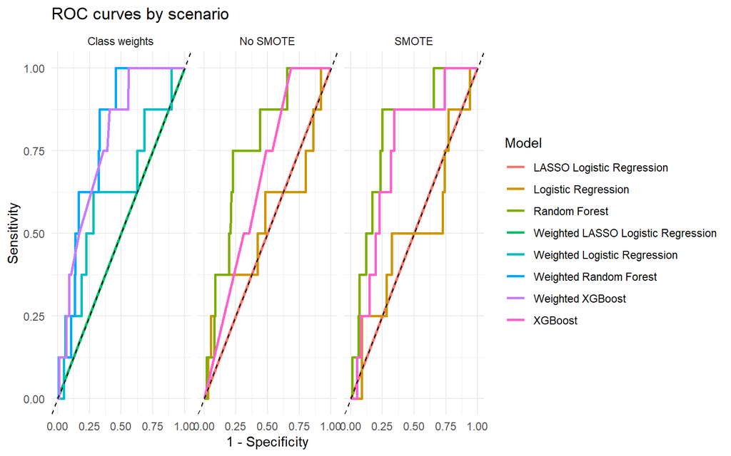

```r
if (!is.null(pred_all) && nrow(pred_all) > 0) {
  pred_all %>%
    group_by(scenario, model) %>%
    roc_curve(truth = Biopsy, .pred_Yes, event_level = "second") %>%
    ggplot(aes(x = 1 - specificity, y = sensitivity, color = model)) +
    geom_path(linewidth = 1) +
    geom_abline(linetype = 2) +
    facet_wrap(~ scenario) +
    labs(title = "ROC curves by scenario", x = "1 - Specificity", y = "Sensitivity", color = "Model") +
    theme_minimal()
}
```

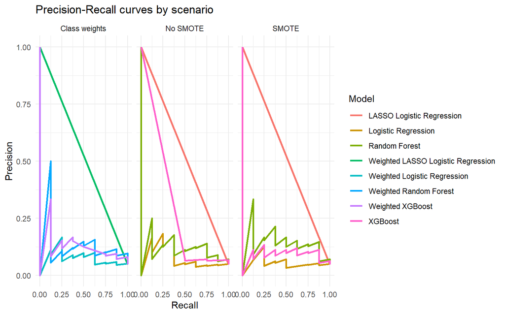

```r
if (!is.null(pred_all) && nrow(pred_all) > 0) {
  pred_all %>%
    group_by(scenario, model) %>%
    pr_curve(truth = Biopsy, .pred_Yes, event_level = "second") %>%
    ggplot(aes(x = recall, y = precision, color = model)) +
    geom_path(linewidth = 1) +
    facet_wrap(~ scenario) +
    labs(title = "Precision-Recall curves by scenario", x = "Recall", y = "Precision", color = "Model") +
    theme_minimal()
}
```

# 8 Best model by scenario

```r
best_by_scenario <- all_results %>%
  group_by(scenario) %>%
  arrange(desc(pr_auc), desc(mcc), desc(roc_auc)) %>%
  slice(1) %>%
  ungroup()

best_by_scenario %>%
  select(scenario, model, pr_auc, mcc, roc_auc, sens, spec, precision, f_meas, brier_class) %>%
  kable(digits = 4, caption = "Best model within each scenario, primarily selected by PR-AUC") %>%
  kable_styling(full_width = FALSE)
```

Best model within each scenario, primarily selected by PR-AUC

| scenario | model | pr_auc | mcc | roc_auc | sens | spec | precision | f_meas | brier_class |
| --- | --- | --- | --- | --- | --- | --- | --- | --- | --- |
| Class weights | Weighted LASSO Logistic Regression | 0.5233 | NA | 0.5 | 0 | 1 | NA | NA | 0.2500 |
| No SMOTE | LASSO Logistic Regression | 0.5233 | NA | 0.5 | 0 | 1 | NA | NA | 0.8275 |
| SMOTE | LASSO Logistic Regression | 0.5233 | NA | 0.5 | 0 | 1 | NA | NA | 0.2500 |

# 9 Automatic interpretation for the thesis

```r
cat("## Main result\n\n")
```

## 9.1 Main result

```r
cat("The best model according to PR-AUC is **", best_pr_auc$model, "** under the **", best_pr_auc$scenario, "** scenario. ", sep = "")
```

The best model according to PR-AUC is **LASSO Logistic Regression** under the **No SMOTE** scenario.

```r
cat("Its PR-AUC is **", round(best_pr_auc$pr_auc, 4), "**, MCC is **", round(best_pr_auc$mcc, 4), "**, sensitivity is **", round(best_pr_auc$sens, 4), "**, and specificity is **", round(best_pr_auc$spec, 4), "**.\n\n", sep = "")
```

Its PR-AUC is **0.5233**, MCC is **NA**, sensitivity is **0**, and specificity is **1**.

```r
cat("The best model according to MCC is **", best_mcc$model, "** under the **", best_mcc$scenario, "** scenario. ", sep = "")
```

The best model according to MCC is **Random Forest** under the **SMOTE** scenario.

```r
cat("Its MCC is **", round(best_mcc$mcc, 4), "** and PR-AUC is **", round(best_mcc$pr_auc, 4), "**.\n\n", sep = "")
```

Its MCC is **0.2934** and PR-AUC is **0.1369**.

```r
cat("Based on the combined ranking of PR-AUC, MCC and ROC-AUC, the most balanced choice is **", best_overall$model, "** under the **", best_overall$scenario, "** scenario.\n\n", sep = "")
```

Based on the combined ranking of PR-AUC, MCC and ROC-AUC, the most balanced choice is **Random Forest** under the **SMOTE** scenario.

```r
cat("## Suggested thesis interpretation\n\n")
```

## 9.2 Suggested thesis interpretation

```r
cat("Because the dataset is highly imbalanced, accuracy should not be used as the main criterion. Instead, PR-AUC and MCC are more suitable because they focus more on the minority class and on the balance between true and false classifications. ")
```

Because the dataset is highly imbalanced, accuracy should not be used as the main criterion. Instead, PR-AUC and MCC are more suitable because they focus more on the minority class and on the balance between true and false classifications.

```r
cat("If one model has the highest PR-AUC but very low sensitivity, it may still be less useful in a medical screening context because it misses many positive biopsy cases. ")
```

If one model has the highest PR-AUC but very low sensitivity, it may still be less useful in a medical screening context because it misses many positive biopsy cases.

```r
cat("A reasonable final model should therefore have a good PR-AUC, a positive MCC, and an acceptable trade-off between sensitivity and specificity.\n\n")
```

A reasonable final model should therefore have a good PR-AUC, a positive MCC, and an acceptable trade-off between sensitivity and specificity.

```r
cat("## Comment about SMOTE and class weights\n\n")
```

## 9.3 Comment about SMOTE and class weights

```r
cat("SMOTE is useful as a comparison method, but it should be interpreted carefully because many variables in this cervical cancer dataset are binary or categorical. Synthetic observations may therefore be less clinically realistic. ")
```

SMOTE is useful as a comparison method, but it should be interpreted carefully because many variables in this cervical cancer dataset are binary or categorical. Synthetic observations may therefore be less clinically realistic.

```r
cat("Class weights are often easier to justify because they keep the original observations unchanged while making errors on the minority class more costly during training. ")
```

Class weights are often easier to justify because they keep the original observations unchanged while making errors on the minority class more costly during training.

```r
cat("Therefore, if class weights perform similarly to or better than SMOTE, the class-weight approach is usually the more defensible method for this thesis.\n")
```

Therefore, if class weights perform similarly to or better than SMOTE, the class-weight approach is usually the more defensible method for this thesis.

# 10 Variable importance

This section compares Random Forest variable importance files if they exist.

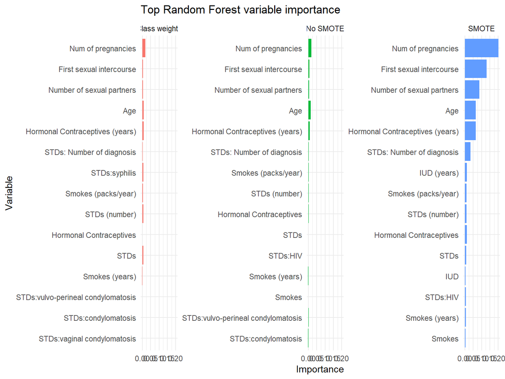

```r
read_importance <- function(file, scenario_name) {
  path <- file.path(base_dir, file)
  if (!file.exists(path)) return(NULL)
  read.csv(path) %>% mutate(scenario = scenario_name)
}

importance_all <- bind_rows(
  read_importance("rf_importance_no_SMOTE.csv", "No SMOTE"),
  read_importance("rf_importance_SMOTE.csv", "SMOTE"),
  read_importance("rf_importance_class_weights.csv", "Class weights")
)

if (!is.null(importance_all) && nrow(importance_all) > 0) {
  importance_top <- importance_all %>%
    group_by(scenario) %>%
    slice_max(order_by = importance, n = 15, with_ties = FALSE) %>%
    ungroup()

  importance_top %>%
    ggplot(aes(x = reorder(variable, importance), y = importance, fill = scenario)) +
    geom_col(show.legend = FALSE) +
    coord_flip() +
    facet_wrap(~ scenario, scales = "free_y") +
    labs(title = "Top Random Forest variable importance", x = "Variable", y = "Importance") +
    theme_minimal()
} else {
  cat("Variable importance CSV files were not found.\n")
}
```

# 11 Final recommendation template

Use this paragraph in the thesis and adjust numbers after knitting the document:

> In this study, four machine learning models were compared under three imbalance-handling scenarios: no resampling, SMOTE, and class weights. Since the outcome variable Biopsy was highly imbalanced, the comparison focused primarily on PR-AUC and MCC rather than accuracy. The results indicated that the best-performing model according to PR-AUC was LASSO Logistic Regression in the No SMOTE scenario. However, the final model choice should also consider sensitivity and specificity. In a medical classification problem, a model with reasonable sensitivity is important because false negatives may be more problematic than false positives. If the class-weight method gives similar performance to SMOTE, it may be preferred because it preserves the original data distribution and does not generate synthetic patient profiles.